# Factors that Affect Loan Status

## by Guwei Zhou

## Investigation Overview

In this investigation, I wanted to look at which factors impact loan status. The main focus was on borrower credit score lower range, borrower APR, loan original amounts, available bank card credit, and the Prosper ratings.

## Dataset Overview

The data consisted of loan status and attributes of 113937 loan listings. To be consistent and accurate with the timeline fot the investigation, I only retrieved data after July 2009 and removed listings with unrealist monthly salary.

## Distribution of Loan Status

66.57% of the loans' status were current, which composes the most part of the loan status. 23.28% of loans are completed. 6.29% of loans were charged off, 1.19% were defaulted, and 2.44% are past due.

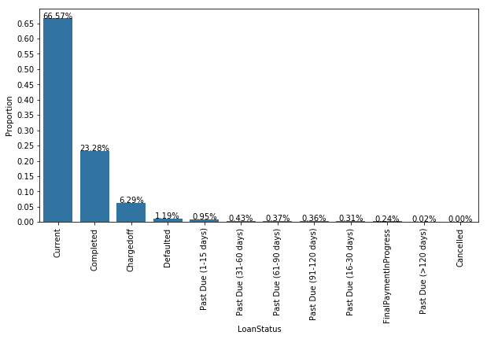

```python
#Since it is difficult to see the exact count, I will convert them into proportions that fall in each category.
n_loan=df2.shape[0]
max_count=df2['LoanStatus'].value_counts().max()
max_prop=max_count/n_loan
base_color=sb.color_palette()[0]
loan_order=df2['LoanStatus'].value_counts().index
#generate the tick mark locations and names
tick_props=np.arange(0, max_prop, 0.05)
tick_names=['{:0.2f}'.format(v) for v in tick_props]
#create the plot
plt.figure(figsize=[10,5])
sb.countplot(data=df2, x='LoanStatus', color=base_color, order=loan_order);
plt.yticks(tick_props*n_loan, tick_names)
plt.ylabel('Proportion');
plt.xticks(rotation=90);
#add annotations
loan_counts=df2['LoanStatus'].value_counts()
locs, labels=plt.xticks()
for loc, label in zip(locs, labels):
    count=loan_counts[label.get_text()]
    plt_string='{:0.2f}%'.format(100*count/n_loan)
    plt.text(loc, count, plt_string, ha='center')
```

## Distribution of Credit Score Lower Range

The distribution of credit score range lower is unimodel and right skewed, with most lower range credit ratings between 660-710.

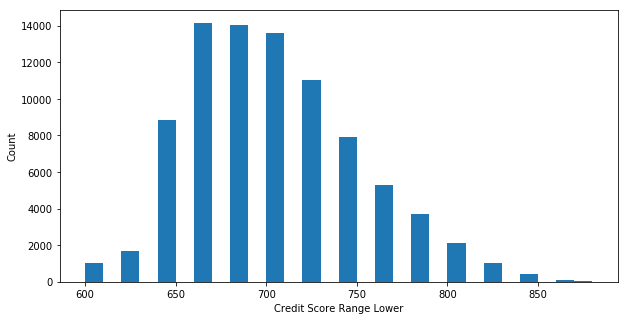

```python
plt.figure(figsize=[10,5])
bin_edges=np.arange(600, 880+10, 10)
plt.hist(data=df2,x='CreditScoreRangeLower', bins=bin_edges);
plt.xlabel('Credit Score Range Lower')
plt.ylabel('Count');
```

## Distribution of Prosper Rating

The distribution of the Prosper rating has an opposite trend with credit score lower range. It has a distribution that skewed to the left, with most ratings concentrated on "C", "B", and "A".

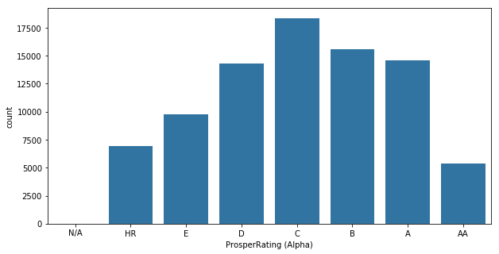

```python
plt.figure(figsize=[10,5])
sb.countplot(data=df2, x='ProsperRating (Alpha)', color=base_color);
```

## Distribution of Borrower APR

There are very large spikes at bars with one digit of precision (especially at 0.37). These spikes probably represent standard loan borrowing rates.

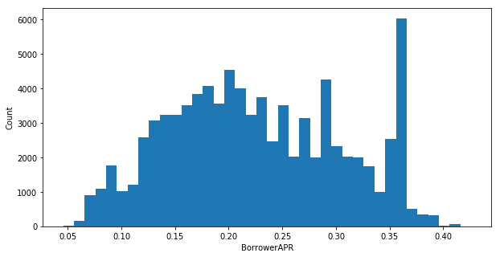

```python
plt.figure(figsize=[10,5])
bins5=np.arange(0.045830, df2['BorrowerAPR'].max()+0.01, 0.01)
plt.hist(data=df2, x='BorrowerAPR', bins=bins5);
plt.xlabel('BorrowerAPR');
plt.ylabel('Count');
```

## Distribution of Loan Amount

For loan orignal amount, there are very large spikes in frequency at the bars with one digit of precision (e.g. 4000, 10000, 15000, 20000, 25000); frequency quickly trails off until the next spike. These probably represent standard loan amounts.

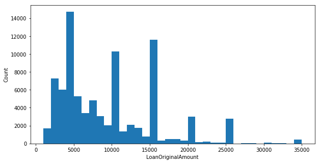

```python
plt.figure(figsize=[10,5])
bins6=np.arange(1000, df2['LoanOriginalAmount'].max()+1000, 1000)
plt.hist(data=df2, x='LoanOriginalAmount', bins=bins6);
plt.xlabel('LoanOriginalAmount');
plt.ylabel('Count');
```

## Loan Status vs Borrower APR, LoanOriginalAmount, Available Bank Card Credit, and CreditScoreRangeLower

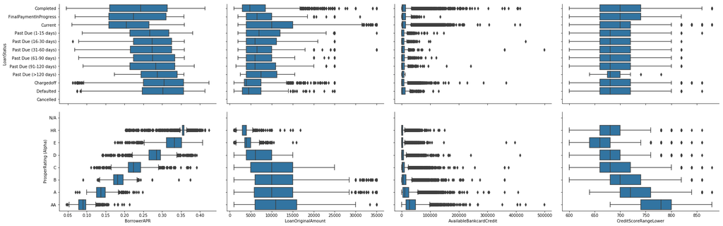

```python
numeric_vars=['CreditScoreRangeLower', 'StatedMonthlyIncome', 'DebtToIncomeRatio', 'EmploymentStatusDuration',
              'AvailableBankcardCredit','LoanOriginalAmount', 'BorrowerAPR']
categoric_vars=['LoanStatus','ProsperRating (Alpha)']
def boxgrid(x, y, **kwargs):
    default_color = sb.color_palette()[0]
    sb.boxplot(x, y, color = default_color)

plt.figure(figsize = [10, 10])
g = sb.PairGrid(data = df2, x_vars = ['BorrowerAPR', 'LoanOriginalAmount', 'AvailableBankcardCredit',
                                           'CreditScoreRangeLower'], y_vars = categoric_vars,
                size = 4, aspect = 1.5)
g=g.map(boxgrid)
```

## Loan Status vs other numeric variables

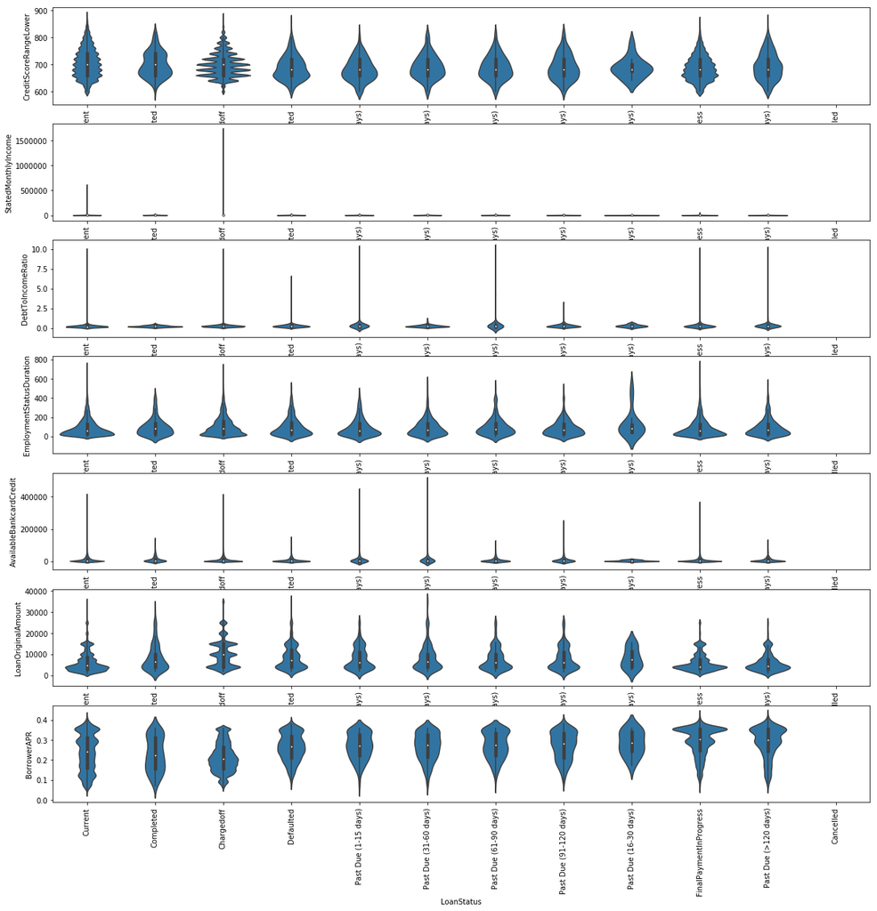

```python
fig, ax = plt.subplots(ncols = 1, nrows= 7, figsize = [20,20])

for i in range(len(numeric_vars)):
    var = numeric_vars[i]
    sb.violinplot(data = df2, y = var, x = 'LoanStatus', color=base_color, ax = ax[i]);
    ax[i].set_xticklabels(labels, rotation=90);
```

## Relationship between Credit Score and APR for each Loan Status

The final payment in progress category has the strongest relationship between borrower APR and credit score. The past due >120 days category has the weakest relationship between borrower APR and credit score.

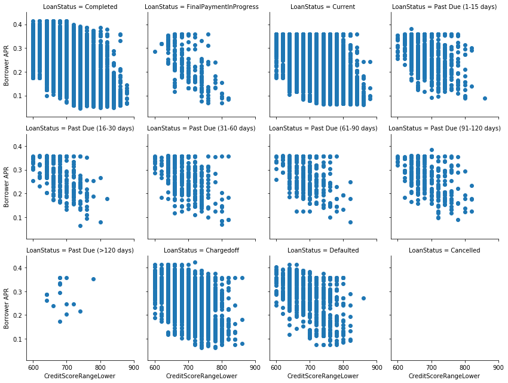

```python
g = sb.FacetGrid(data = df2, col = 'LoanStatus', col_wrap = 4, size = 3)
g.map(plt.scatter,'CreditScoreRangeLower', 'BorrowerAPR')
g.set_xlabels('CreditScoreRangeLower')
g.set_ylabels('Borrower APR')
```

## Relationship between Credit Score and Prosper rating for each loan status

Surprisingly HR (high risk) rating actually has higher credit score than rating E, which is the next riskiest rating, and about the same credit score with rating D.

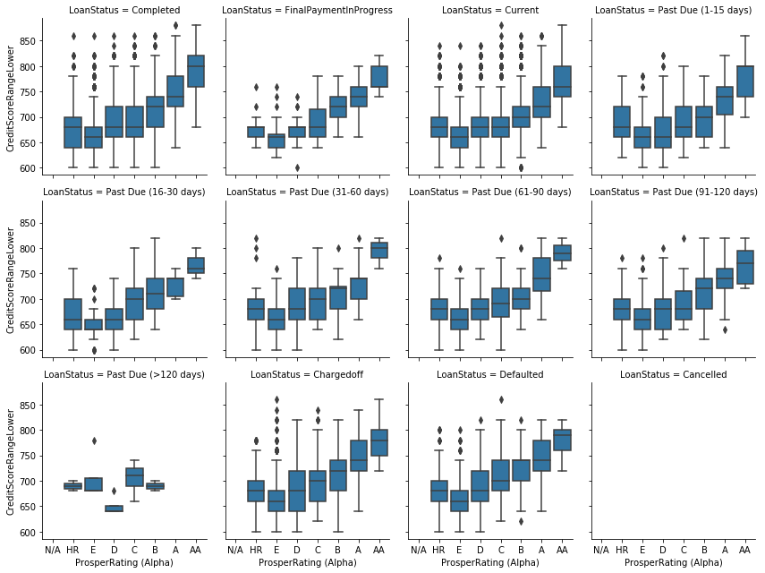

```python
g = sb.FacetGrid(data = df2, col = 'LoanStatus', col_wrap = 4, size = 3)
g.map(sb.boxplot,'ProsperRating (Alpha)', 'CreditScoreRangeLower');
g.set_xlabels('ProsperRating (Alpha)')
g.set_ylabels('CreditScoreRangeLower')
```

## Relationship between borrower APR and Prosper rating for each loan status

Borrower APR are aligned with my thoughts, with HR rating having highest APR, and AA rating having the lowest APR.

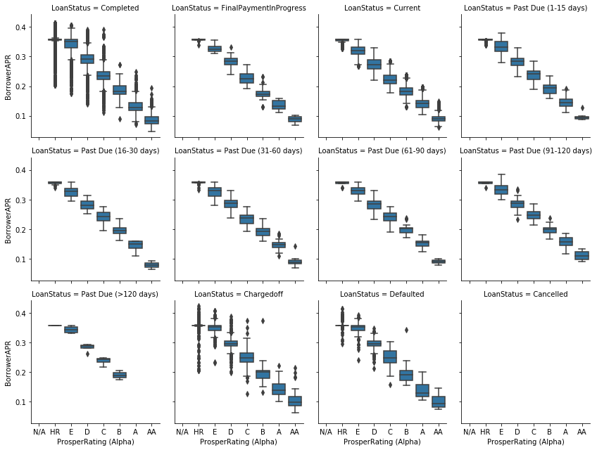

```python
g = sb.FacetGrid(data = df2, col = 'LoanStatus', col_wrap = 4, size = 3)
g.map(sb.boxplot,'ProsperRating (Alpha)', 'BorrowerAPR');
g.set_xlabels('ProsperRating (Alpha)')
g.set_ylabels('BorrowerAPR')
```